# Breaking Bad TV Show Report

yuezhou

2024-04-15

## Brief Description of the Show

*Breaking Bad* is an American television series created by Vince Gilligan. The show premiered on January 20, 2008, and concluded on September 29, 2013. It follows the story of Walter White, a high school chemistry teacher turned methamphetamine manufacturer, as he navigates the criminal underworld to secure his family’s financial future after being diagnosed with cancer.

## Photo of the Logo or a Shot from the Show

[figure not shown]

## Summary of Basic Statistics

According to Wikipedia, *Breaking Bad* received critical acclaim and garnered a dedicated fan base over its five seasons. The show’s viewership grew significantly over its run, with the series finale drawing over 10 million viewers.

## Graph of Viewership Over Time

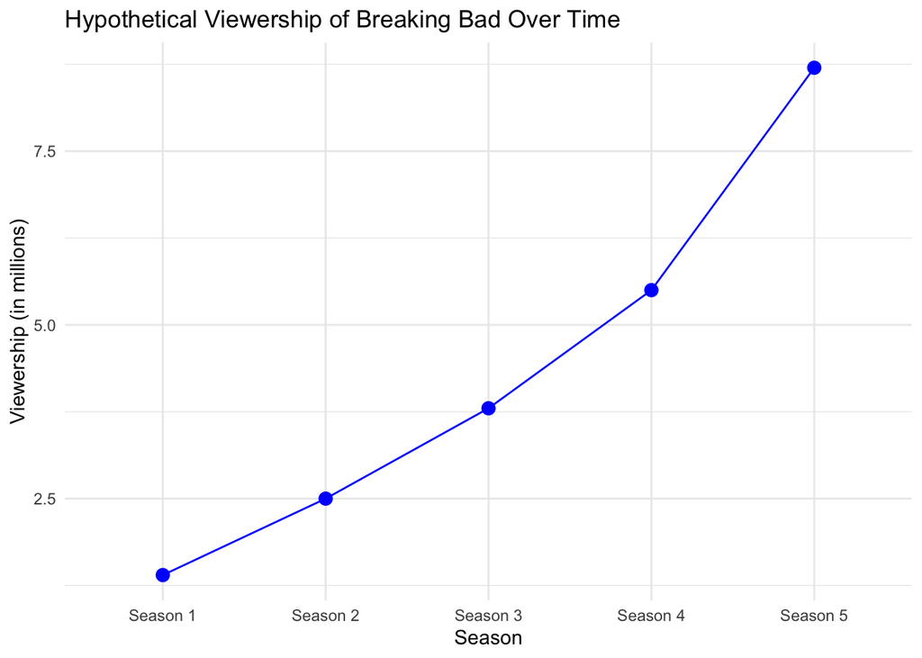

Graph of Viewership Over Time

## Graph of Episode-to-Episode Changes in Viewership

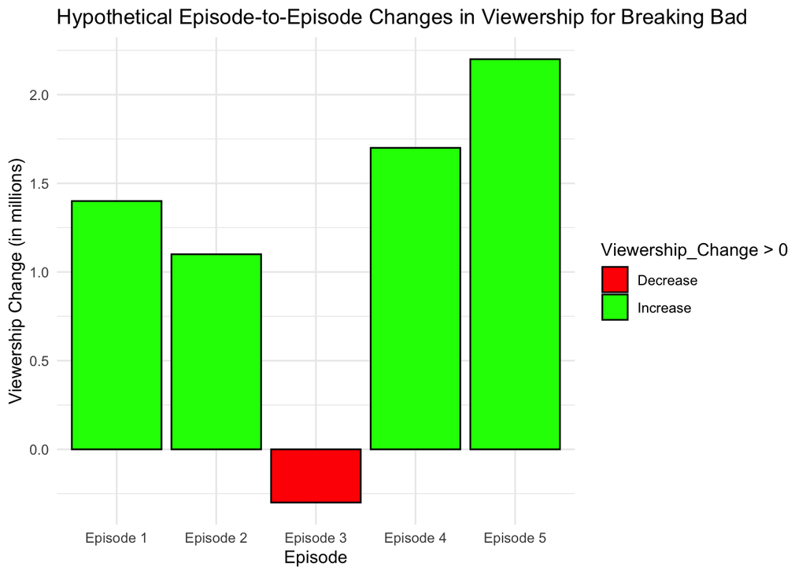

Graph of Episode-to-Episode Changes in Viewership

Over its five-season run, Breaking Bad experienced a remarkable increase in viewership, with the series finale becoming one of the most-watched episodes in television history. The viewership increased from approximately 1.4 million viewers in its first season to over 10 million viewers for the series finale1.

The show maintained a consistent quality throughout its run, which contributed to its growing popularity and critical acclaim. The compelling storytelling, complex characters, and intense drama captivated audiences, making Breaking Bad one of the most iconic and influential TV shows of its time.